# Computational Bayesian Statistics (Ch.20)

AG Schissler

04/13/2020

## How to do Bayesian statistics when you can’t easily derive or numerically approximate the posterior?

### Start-of-class work

#### Visual Intro to MCMC

First let’s see some visualizations of sampling the posterior using different approaches:

[mcmc demo](https://chi-feng.github.io/mcmc-demo/)

#### Sampling the posterior

Discuss Example 20.1. Similar to HW 10 #1.

#### Starting Unit 4: Computational Bayesian Methods and Advanced Regression

I’ll make lecture notes Bolstad & Curran and

[Data Analysis Using Regression and Multilevel/Hierarchical Models (Gelman and Hill 2007)](https://www.amazon.com/Analysis-Regression-Multilevel-Hierarchical-Models/dp/052168689X)

and

[Statistical Computing with R (Rizzo 2006)](https://www.amazon.com/Statistical-Computing-Chapman-Hall-CRC/dp/1584885459)

possibly other sources.

## Ch. 20 intro. Bayesian Statistics: Easy in Theory, Difficult in Practice

Discussion of text material.

## Section 20.1.Direct methods for sampling the posterior

Discussion of text material.

### Inverse probability sampling

Discuss text and Figure 20.2, Example 20.2.

Classroom exercise: A random variable $y$ is called exponential with **rate** $\lambda$ if it has cdf $F(y)= \lambda e^{- \lambda y}$ for $y \geq 0$ and $\lambda>0$. Let $y \sim exp(\lambda=2$). Use inverse probability sampling to create a random sample of size 10,000 from this exponential distribution. Reproduce Figure 20.3 to visualize your sample.

[A list of the distributions in the `stats` package](https://stat.ethz.ch/R-manual/R-devel/library/stats/html/Distributions.html)

```r
## our work goes here
```

### An example of inverse probability sampling and computing

Xiang Li, A. Grant Schissler, Rui Wu, Lee Barford, and Frederick C. Harris, Jr. A graphical processing unit accelerated NORmal To Anything algorithm for high dimensional multivariate simulation *Advances in Intelligent Systems and Computing*, Volume 800, Chapter 46, pp 339-346. *Proceedings of the 16th International Conference on Information Technology : New Generations (ITNG 2019)* April 1-3, Las Vegas, NV.

### Acceptance–Rejection Sampling

Discuss the algorithm and example.

### Adaptive–Rejection Sampling

I’ll briefly mention the point of the section and move on.

## Section 20.2 Sampling Importance Resampling

### Importance sampling

Discuss text examples and figures.

```r
## Here I'll provide some code to reproduce Figure 20.10
```

## Section 20.3. Markov Chain Monte Carlo (MCMC) Methods

### The Metropolis-Hastings Algorithm (1970)

From Rizzo 2006,

The *Metropolis-Hastings sampler* generates a Markov chain $\{X_0, X_1, \ldots \}$ as follows:

1. Choose a proposal distribution $g(\cdot | X_t)$, subject to regularity conditions discussed below.
2. Generate $X_0$ from distribution $g$.
3. Repeat (until chain has convergened to a stationary distribution):
   1. Generate $Y$ from $g(\cdot | X_t)$.
   2. Generate $U$ from Uniform(0,1).
   3. If
      $$U \leq \frac{f(Y)g(X_t|Y)}{f(X_t)g(Y|X_t)}$$
      accept $Y$ and set $X_{t+1} = Y$; otherwise set $X_{t+1} = X_t$.
   4. Increment $t$.

Observe that in step (3c) the candidate point $Y$ is accepted with probability
$$\alpha (X_t, Y) = min \left( 1, \frac{f(Y)g(X_t|Y)}{f(X_t)g(Y|X_t)} \right),$$

So it is only necessary to know the density of the target distribution $f$ up to a constant!

The algorithm is designed so that the stationary distribution of the chain is $f$.

The proposal distribution must be chosen so that the generated chain will converge to a stationary distribution — the target distribution. A proposal distribution with the same support as the target distribution will generally satisify regularity conditions (irreducibility, positive recurrence, and aperiodicity) to guarantee convergence.

### The Metropolis Sampler (1953)

Note that Metropolis-Hastings is a generalized of the slightly older Metropolis algorithm.

In the Metropolis algorithm, proposal distribution $g$ must be symmetric. I.e., $g(X|Y)=g(Y|X)$.

Then the acceptance ratio

$$r(X_t, Y) = \frac{f(Y)g(X_t|Y)}{f(X_t)g(Y|X_t)}$$

simplies to

$$r(X_t, Y) = \frac{f(Y)}{f(X_t)}.$$

This generalization provides greater efficiency (more rapid convergence to the stationary distribution) in certain cases.

### Example from Rizzo 2006, the Rayleigh distribution

Let’s use the M-H algorithm to generate a sample from the Rayleigh distribution. The Rayleigh distribution has density

$f(x) = \frac{x}{\sigma^2}e^{-x^2/(2\sigma^2)}, x \geq 0, \sigma > 0$

The Rayleigh distribution is used to model lifetimes subject to rapid aging. The mode is $\sigma$, $E[X] = \sigma \sqrt{\pi / 2}$ and $Var(X) = \sigma^2 (4-\pi) /2$.

For the proposal distribution, try the chi-squared distribution with degrees of freedom of $X_t$.

In R,

```r
## define Rayleigh density
f <- function(x, sigma) {
    if (any(x < 0)) return(0)
    stopifnot(sigma > 0)
    return((x / sigma^2) * exp(-x^2 / (2*sigma^2)))
}

## construct the chain
m <- 10000
sigma <- 4
x <- numeric(m)
x[1] <- rchisq(1, df = 1)
k <- 0 ## rejections to investigate efficiency
u <- runif(m) ## acceptance probabilities

for (i in 2:m) {
    xt <- x[i-1]
    y <- rchisq(1, df = xt)
    num <- f(y, sigma) * dchisq(xt, df = y)
    den <- f(xt, sigma) * dchisq(y, df = xt)
    if (u[i] <= num/den) {
        x[i] <- y
    } else {
        ## y is rejected
        x[i] <- xt
        k <- k + 1
    }
}

print(k) / m
```

```
## [1] 4019
```

```
## [1] 0.4019
```

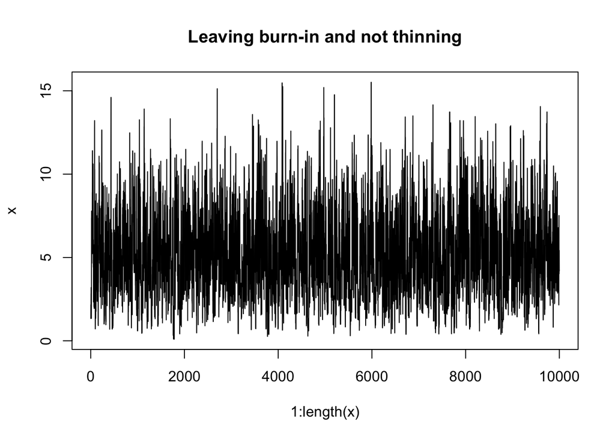

```r
## go past burn-in and thin
index <- seq(3000, 10000, by = 10)
y1 <- x[index]
plot(1:length(x), x, type = "l", main = "Leaving burn-in and not thinning", ylab = "x")
```

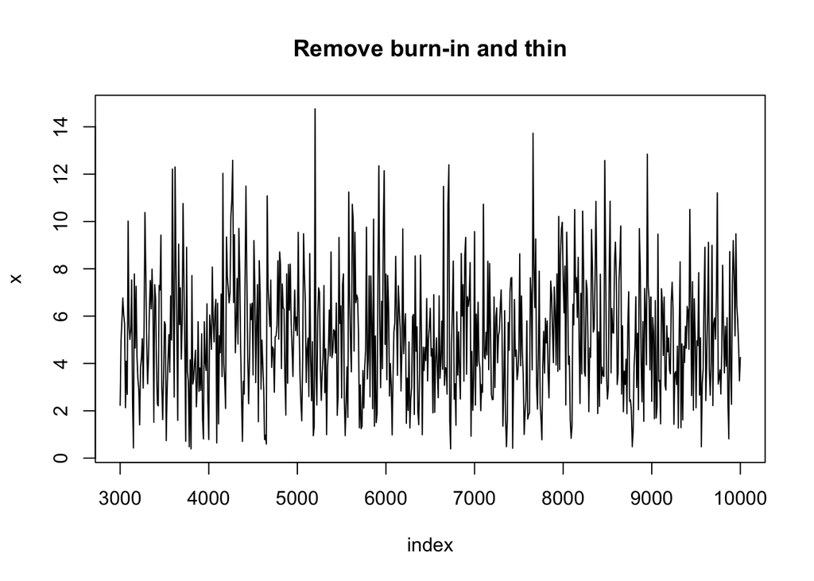

```r
plot(index, y1, type = "l", main = "Remove burn-in and thin", ylab = "x")
```

Check the expected value.

```r
## expected value
mean(y1)
```

```
## [1] 5.114385
```

```r
mean(x)
```

```
## [1] 5.034475
```

```r
## in theory
sigma * sqrt(pi /2)
```

```
## [1] 5.013257
```

### Gibbs Sampling

- Discuss big ideas of Gibbs Sampling and why it is important.
- We’ll see Gibbs later in this final Unit.

## Closing

3-2-1:

3 Techniques learned today  
2 New ideas you encountered  
1 Question you have